### Telecommunication Industry Project

# Introduction

This Jupyter notebook is part of your learning experience in the study of applied statistics.

You will work with a data set that contains mobile phone prices and their specifications.

**Dataset Columns Information**

PID = a unique identifier for the phone model

Blue = whether the phone has bluetooth support or not

Wi_Fi = whether the phone has wifi support or not

Tch_Scr = whether the phone has touch screen support or not

Ext_Mem = whether the phone has external memory support or not

Px_h = number of pixels in the vertical axis of the phone

Px_w = number of pixels in the horizontal axis of the phone

Scr_h = height of the screen of the phone in centimetres (cm)

Scr_w = width of the screen of the phone in centimetres (cm)

Int_Mem = internal memory of the phone measured in megabytes (MB)

Bty_Pwr = maximum energy stored by the phone's battery measured in milli-Ampere-hours (mAh)

PC = resolution of the primary camera measued in megapixels (MP)

FC = resolution of the front camera measued in megapixels (MP)

RAM = random access memory available in the phone measured in gigabytes (GB)

Depth = depth of the mobile phone measured in centimetres (cm)

Weight = weight of the mobile phone measured in grams (g)

Price = selling price of the mobile phone in rupees

## Task 1 - Load and study the data

Import the libraries that will be used in this notebook

```python
# Load "numpy" and "pandas" for manipulating numbers and data frames
# Load "matplotlib.pyplot" and "seaborn" for data visualisation
import pandas as pd
import numpy as np
import seaborn as sns
import matplotlib.pyplot as plt
```

Load the csv file as pandas dataframe.

```python
# Read in the "Dataset" file as a Pandas Data Frame
df = pd.read_csv("Telecom Dataset.csv")
```

```python
# Take a brief look at the data
df.head()
```

|  | PID | Blue | Wi_Fi | Tch_Scr | Ext_Mem | Px_h | Px_w | Scr_h | Scr_w | PC | FC | Int_Mem | Bty_Pwr | RAM | Depth | Weight | Price |
| --- | --- | --- | --- | --- | --- | --- | --- | --- | --- | --- | --- | --- | --- | --- | --- | --- | --- |
| 0 | AAB346A | yes | yes | no | no | 780 | 460 | 3 | 1 | 2 | 2 | 8 | 2800 | 2 | 7 | 320 | 3297 |
| 1 | AAC347I | yes | yes | no | no | 780 | 560 | 2 | 1 | 4 | 2 | 8 | 3000 | 2 | 7 | 280 | 4500 |
| 2 | BAB657J | no | yes | no | no | 840 | 720 | 2 | 1 | 4 | 2 | 8 | 3300 | 2 | 7 | 400 | 4898 |
| 3 | BBD456K | no | yes | yes | no | 1280 | 1120 | 5 | 3 | 6 | 2 | 32 | 3000 | 2 | 3 | 300 | 6900 |
| 4 | CCP761U | no | yes | yes | no | 1280 | 1080 | 4 | 3 | 6 | 2 | 16 | 3000 | 2 | 3 | 210 | 5600 |

```python
# Get the dimensions of the dataframe
df.shape
```

```
(50, 17)
```

```python
# Get the row names of the dataframe
row_names = df.index
print(row_names)
```

```
RangeIndex(start=0, stop=50, step=1)
```

```python
# Get the column names of the dataframe
column_names = df.columns
print(column_names)
```

```
Index(['PID', 'Blue', 'Wi_Fi', 'Tch_Scr', 'Ext_Mem', 'Px_h', 'Px_w', 'Scr_h',
       'Scr_w', 'PC', 'FC', 'Int_Mem', 'Bty_Pwr', 'RAM', 'Depth', 'Weight',
       'Price'],
      dtype='object')
```

```python
# Look at basic information about the dataframe
print(df.info())
```

```
<class 'pandas.core.frame.DataFrame'>
RangeIndex: 50 entries, 0 to 49
Data columns (total 17 columns):
 #   Column   Non-Null Count  Dtype
---  ------   --------------  -----
 0   PID      50 non-null     object
 1   Blue     50 non-null     object
 2   Wi_Fi    50 non-null     object
 3   Tch_Scr  50 non-null     object
 4   Ext_Mem  50 non-null     object
 5   Px_h     50 non-null     int64
 6   Px_w     50 non-null     int64
 7   Scr_h    50 non-null     int64
 8   Scr_w    50 non-null     int64
 9   PC       50 non-null     int64
 10  FC       50 non-null     int64
 11  Int_Mem  50 non-null     int64
 12  Bty_Pwr  50 non-null     int64
 13  RAM      50 non-null     int64
 14  Depth    50 non-null     int64
 15  Weight   50 non-null     int64
 16  Price    50 non-null     int64
dtypes: int64(12), object(5)
memory usage: 6.8+ KB
None
```

Observations:

There are 50 phones in the data set.

There are no missing values in the data set.

```python
df.isnull().sum()
```

```
PID        0
Blue       0
Wi_Fi      0
Tch_Scr    0
Ext_Mem    0
Px_h       0
Px_w       0
Scr_h      0
Scr_w      0
PC         0
FC         0
Int_Mem    0
Bty_Pwr    0
RAM        0
Depth      0
Weight     0
Price      0
dtype: int64
```

Let's try some logical operators to filter the data.

[figure not shown]

## Task 2 - Obtain the logical conditions for the features "Blue", "Wi_Fi", "Tch_Scr" and "Ext_Mem"

```python
# Get the feature names of the dataframe
blue_values = df['Blue'].unique()
wifi_values = df['Wi_Fi'].unique()
touchscreen_values = df['Tch_Scr'].unique()
ext_mem_values = df['Ext_Mem'].unique()

print("Unique values for 'Blue':", blue_values)
print("Unique values for 'Wi_Fi':", wifi_values)
print("Unique values for 'Tch_Scr':", touchscreen_values)
print("Unique values for 'Ext_Mem':", ext_mem_values)
```

```
Unique values for 'Blue': ['yes' 'no']
Unique values for 'Wi_Fi': ['yes' 'no']
Unique values for 'Tch_Scr': ['no' 'yes']
Unique values for 'Ext_Mem': ['no' 'yes']
```

```python
# Let's tackle these features: "Blue", "Wi_Fi", "Tch_Scr", "Ext_Mem"
```

```python
# The children want phones that have the following: Bluetooth, WiFi, touch screen and external memory support
# Create a logical condition for this situation and store the logical values as "con1"

con1 = (df['Blue'] == 'yes') & (df['Wi_Fi'] == 'yes') & (df['Tch_Scr'] == 'yes') & (df['Ext_Mem'] == 'yes')

# Filter the DataFrame using the condition
result_df = df[condition]
result_df
```

[output not shown]

Observations:

The features "Blue", "Wi_Fi", "Tch_Scr" and "Ext_Mem" are binary in nature.

The children want all these features, so the logical condition "con1" has been obtained accordingly.

## Task 3 - Obtain the logical conditions for the features "Px_h" and "Px_w"

```python
# Get the feature names of the dataframe
feature_names = df.columns
print("Feature names of the DataFrame:", feature_names)
```

```
Feature names of the DataFrame: Index(['PID', 'Blue', 'Wi_Fi', 'Tch_Scr', 'Ext_Mem', 'Px_h', 'Px_w', 'Scr_h',
       'Scr_w', 'PC', 'FC', 'Int_Mem', 'Bty_Pwr', 'RAM', 'Depth', 'Weight',
       'Price'],
      dtype='object')
```

```python
# Let's tackle these features: "Px_h", "Px_w"
```

```python
# Create a new feature called "Px" which stores the total resolution of the screen
df['Px'] = df['Px_h'] * df['Px_w']
df.head()
```

|  | PID | Blue | Wi_Fi | Tch_Scr | Ext_Mem | Px_h | Px_w | Scr_h | Scr_w | PC | FC | Int_Mem | Bty_Pwr | RAM | Depth | Weight | Price | Px |
| --- | --- | --- | --- | --- | --- | --- | --- | --- | --- | --- | --- | --- | --- | --- | --- | --- | --- | --- |
| 0 | AAB346A | yes | yes | no | no | 780 | 460 | 3 | 1 | 2 | 2 | 8 | 2800 | 2 | 7 | 320 | 3297 | 358800 |
| 1 | AAC347I | yes | yes | no | no | 780 | 560 | 2 | 1 | 4 | 2 | 8 | 3000 | 2 | 7 | 280 | 4500 | 436800 |
| 2 | BAB657J | no | yes | no | no | 840 | 720 | 2 | 1 | 4 | 2 | 8 | 3300 | 2 | 7 | 400 | 4898 | 604800 |
| 3 | BBD456K | no | yes | yes | no | 1280 | 1120 | 5 | 3 | 6 | 2 | 32 | 3000 | 2 | 3 | 300 | 6900 | 1433600 |
| 4 | CCP761U | no | yes | yes | no | 1280 | 1080 | 4 | 3 | 6 | 2 | 16 | 3000 | 2 | 3 | 210 | 5600 | 1382400 |

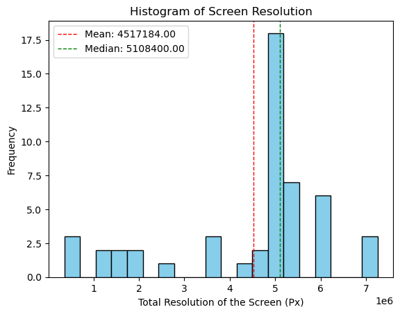

```python
# Create a histogram of the "Px" feature and also show the mean and the median
plt.hist(df['Px'], bins=20, color='skyblue', edgecolor='black')
plt.xlabel('Total Resolution of the Screen (Px)')
plt.ylabel('Frequency')
plt.title('Histogram of Screen Resolution')

mean_px = df['Px'].mean()
median_px = df['Px'].median()

plt.axvline(mean_px, color='red', linestyle='dashed', linewidth=1, label=f'Mean: {mean_px:.2f}')
plt.axvline(median_px, color='green', linestyle='dashed', linewidth=1, label=f'Median: {median_px:.2f}')
plt.legend()

plt.show()
```

```python
# The children want phones that have good screen resolutions
# Consider the phones that have screen resolutions greater than or equal to the median value in the data set
# Create a logical condition for this situation and store the logical values as "con2"

median_screen_resolution = df['Px'].median()
con2 = df['Px'] >= median_screen_resolution
df[con2]
```

[output not shown]

Observations:

The features "Px_h" and "Px_w" are respectively the number of pixels in the phone screen in the vertical and horizontal axes.

We created a new feature called "Px" which is the product of the features "Px_h" and "Px_w".

The median has been selected as a threshold in this case.

In case it is too strict, we can choose the mean as a threshold.

# Task 4 - Obtain the logical conditions for the features "Scr_h" and "Scr_w"

```python
# Let's tackle these features: "Scr_h", "Scr_w"
```

```python
# Create a new feature called "Scr_d" which stores the length of the diagonal of the screen of the phone

df['Scr_d'] = np.sqrt(df['Scr_h']**2 + df['Scr_w']**2)
```

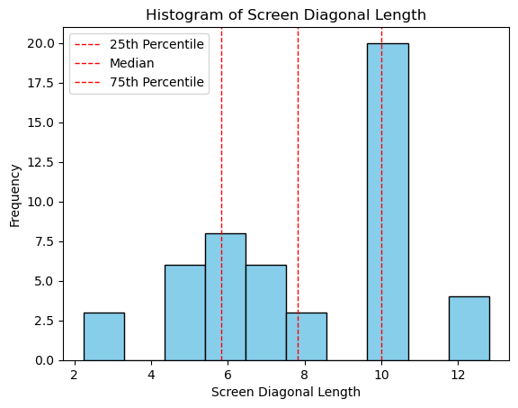

```python
# Create a histogram of the "Scr_d" feature and also show the quartiles
plt.hist(df['Scr_d'], bins=10, color='skyblue', edgecolor='black')

plt.xlabel('Screen Diagonal Length')
plt.ylabel('Frequency')
plt.title('Histogram of Screen Diagonal Length')

quartiles = np.percentile(df['Scr_d'], [25, 50, 75])
for q in quartiles:
    plt.axvline(q, color='red', linestyle='--', linewidth=1)

plt.legend(['25th Percentile', 'Median', '75th Percentile'])

plt.show()
```

```python
# The children want phones that have very good screen sizes
# Consider the phones that have screen sizes greater than or equal to the upper quartile value in the data set
# Create a logical condition for this situation and store the logical values as "con3"
upper_quartile = np.percentile(df['Scr_d'], 75)
con3 = df['Scr_d'] >= upper_quartile
df[con3]
```

|  | PID | Blue | Wi_Fi | Tch_Scr | Ext_Mem | Px_h | Px_w | Scr_h | Scr_w | PC | FC | Int_Mem | Bty_Pwr | RAM | Depth | Weight | Price | Px | Scr_d |
| --- | --- | --- | --- | --- | --- | --- | --- | --- | --- | --- | --- | --- | --- | --- | --- | --- | --- | --- | --- |
| 7 | DFR256N | yes | no | no | no | 2880 | 2120 | 8 | 6 | 12 | 8 | 32 | 3200 | 2 | 3 | 80 | 15600 | 6105600 | 10.000000 |
| 11 | ELS333L | yes | yes | yes | yes | 2580 | 1920 | 8 | 6 | 64 | 32 | 8 | 4500 | 8 | 4 | 150 | 43980 | 4953600 | 10.000000 |
| 15 | NSD450I | no | no | yes | yes | 1980 | 1760 | 10 | 8 | 16 | 16 | 128 | 3900 | 6 | 4 | 180 | 23456 | 3484800 | 12.806248 |
| 16 | PDF768G | no | no | yes | yes | 2580 | 1980 | 8 | 6 | 64 | 32 | 128 | 3300 | 4 | 3 | 160 | 22650 | 5108400 | 10.000000 |
| 17 | PDG234M | no | no | yes | yes | 2880 | 2120 | 8 | 6 | 8 | 8 | 64 | 2800 | 4 | 3 | 250 | 19806 | 6105600 | 10.000000 |
| 18 | PEL111K | no | no | yes | yes | 1980 | 1760 | 8 | 6 | 12 | 4 | 8 | 4000 | 4 | 3 | 330 | 11388 | 3484800 | 10.000000 |
| 21 | QWR222Y | no | yes | yes | yes | 2580 | 1980 | 8 | 6 | 64 | 32 | 128 | 4400 | 4 | 3 | 160 | 21350 | 5108400 | 10.000000 |
| 23 | RAY344W | no | yes | yes | yes | 2880 | 2120 | 10 | 8 | 8 | 4 | 16 | 4800 | 8 | 3 | 170 | 18900 | 6105600 | 12.806248 |
| 27 | SFK567Y | yes | yes | yes | yes | 2580 | 2120 | 8 | 6 | 64 | 16 | 32 | 4300 | 8 | 3 | 200 | 49899 | 5469600 | 10.000000 |
| 28 | SSD000L | yes | yes | yes | yes | 2580 | 2120 | 8 | 6 | 64 | 32 | 512 | 4200 | 8 | 3 | 270 | 36555 | 5469600 | 10.000000 |
| 29 | SYL888P | no | yes | yes | yes | 2580 | 2120 | 8 | 6 | 64 | 16 | 256 | 5000 | 8 | 3 | 320 | 32459 | 5469600 | 10.000000 |
| 30 | TVF078Y | yes | yes | yes | yes | 2580 | 2120 | 8 | 6 | 64 | 32 | 512 | 4860 | 8 | 3 | 90 | 29999 | 5469600 | 10.000000 |
| 31 | TYQ109G | no | yes | yes | yes | 2580 | 2120 | 8 | 6 | 32 | 16 | 256 | 3300 | 8 | 3 | 110 | 45899 | 5469600 | 10.000000 |
| 32 | TYS938L | yes | yes | yes | yes | 2580 | 2120 | 8 | 6 | 64 | 32 | 1024 | 4860 | 8 | 3 | 120 | 46777 | 5469600 | 10.000000 |
| 33 | TYU444Q | no | yes | yes | yes | 2580 | 2120 | 8 | 6 | 64 | 32 | 128 | 2800 | 8 | 3 | 120 | 45680 | 5469600 | 10.000000 |
| 36 | UST000T | yes | yes | yes | yes | 2580 | 1980 | 10 | 8 | 64 | 32 | 32 | 3000 | 4 | 4 | 240 | 34589 | 5108400 | 12.806248 |
| 41 | WUV902Y | yes | yes | yes | yes | 2580 | 1980 | 8 | 6 | 48 | 16 | 128 | 3400 | 4 | 3 | 140 | 28000 | 5108400 | 10.000000 |
| 42 | WZB298K | yes | yes | yes | yes | 2580 | 1980 | 8 | 6 | 64 | 32 | 1024 | 5600 | 8 | 3 | 160 | 39000 | 5108400 | 10.000000 |
| 43 | XKL901R | no | yes | yes | yes | 2580 | 1980 | 8 | 6 | 32 | 16 | 256 | 3900 | 4 | 3 | 210 | 54320 | 5108400 | 10.000000 |
| 44 | XTL675G | yes | yes | yes | yes | 2580 | 1980 | 10 | 8 | 64 | 32 | 512 | 4560 | 8 | 3 | 260 | 51230 | 5108400 | 12.806248 |
| 45 | XXV567F | no | yes | yes | yes | 2580 | 1980 | 8 | 6 | 64 | 32 | 64 | 2300 | 4 | 3 | 250 | 43990 | 5108400 | 10.000000 |
| 47 | ZDF789K | yes | yes | yes | no | 2880 | 2520 | 8 | 6 | 64 | 32 | 512 | 5600 | 12 | 2 | 80 | 84566 | 7257600 | 10.000000 |
| 48 | ZEO567M | yes | yes | yes | no | 2880 | 2520 | 8 | 6 | 128 | 64 | 512 | 5600 | 12 | 2 | 110 | 88999 | 7257600 | 10.000000 |
| 49 | ZZZ909X | yes | yes | yes | no | 2880 | 2520 | 8 | 6 | 128 | 64 | 1024 | 5600 | 12 | 2 | 130 | 149000 | 7257600 | 10.000000 |

Observations:

The features "Scr_h" and "Scr_w" are respectively the height and the width of the phone screen.

We created a new feature called "Scr_d" which is essentially the length of the screen diagonal.

The upper quartile has been selected as a threshold in this case as the children were very particular on this point.

In case it is too strict, we can choose the mean or the median as a threshold.

# Task 5 - Obtain the logical conditions for the features "PC" and "FC"

```python
# Let's tackle these features: "PC", "FC"
```

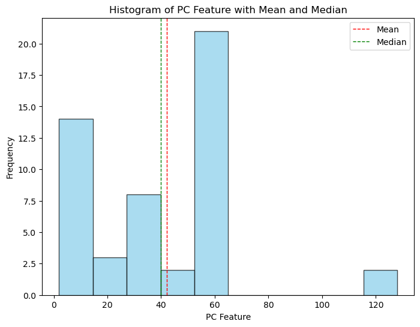

```python
# Create a histogram of the "PC" feature and also show the mean and the median
con_PC = df['PC'] > df['PC'].median()
con_FC = df['FC'] > df['FC'].median()

plt.figure(figsize=(8, 6))
plt.hist(df['PC'], bins=10, color='skyblue', edgecolor='black', alpha=0.7)
plt.axvline(df['PC'].mean(), color='red', linestyle='dashed', linewidth=1, label='Mean')
plt.axvline(df['PC'].median(), color='green', linestyle='dashed', linewidth=1, label='Median')
plt.xlabel('PC Feature')
plt.ylabel('Frequency')
plt.title('Histogram of PC Feature with Mean and Median')
plt.legend()
plt.show()
```

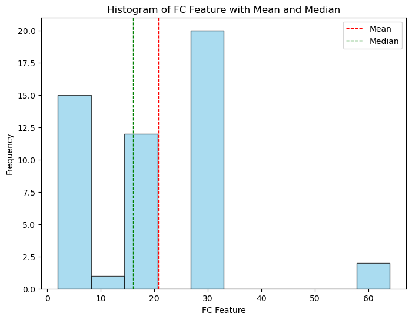

```python
# Create a histogram of the "FC" feature and also show the mean and the median
plt.figure(figsize=(8, 6))
plt.hist(df['FC'], bins=10, color='skyblue', edgecolor='black', alpha=0.7)
plt.axvline(df['FC'].mean(), color='red', linestyle='dashed', linewidth=1, label='Mean')
plt.axvline(df['FC'].median(), color='green', linestyle='dashed', linewidth=1, label='Median')
plt.xlabel('FC Feature')
plt.ylabel('Frequency')
plt.title('Histogram of FC Feature with Mean and Median')
plt.legend()
plt.show()
```

```python
# The children want phones that have good primary and front camera resolutions
# Consider the phones that have primary and front camera resolutions greater than or equal to their respective mean values
# Create a logical condition for this situation and store the logical values as "con4"
mean_pc = df['PC'].mean()
mean_fc = df['FC'].mean()
con4_pc = df['PC'] >= mean_pc
con4_fc = df['FC'] >= mean_fc

con4 = con4_pc & con4_fc
df[con4]
```

|  | PID | Blue | Wi_Fi | Tch_Scr | Ext_Mem | Px_h | Px_w | Scr_h | Scr_w | PC | FC | Int_Mem | Bty_Pwr | RAM | Depth | Weight | Price | Px | Scr_d |
| --- | --- | --- | --- | --- | --- | --- | --- | --- | --- | --- | --- | --- | --- | --- | --- | --- | --- | --- | --- |
| 9 | ENG897N | yes | yes | yes | yes | 2580 | 1980 | 5 | 3 | 64 | 32 | 64 | 4380 | 4 | 3 | 150 | 23456 | 5108400 | 5.830952 |
| 11 | ELS333L | yes | yes | yes | yes | 2580 | 1920 | 8 | 6 | 64 | 32 | 8 | 4500 | 8 | 4 | 150 | 43980 | 4953600 | 10.000000 |
| 12 | ETT987D | no | yes | yes | yes | 2580 | 1980 | 6 | 5 | 64 | 32 | 64 | 4500 | 6 | 4 | 300 | 28700 | 5108400 | 7.810250 |
| 16 | PDF768G | no | no | yes | yes | 2580 | 1980 | 8 | 6 | 64 | 32 | 128 | 3300 | 4 | 3 | 160 | 22650 | 5108400 | 10.000000 |
| 21 | QWR222Y | no | yes | yes | yes | 2580 | 1980 | 8 | 6 | 64 | 32 | 128 | 4400 | 4 | 3 | 160 | 21350 | 5108400 | 10.000000 |
| 25 | SDO555G | no | yes | yes | yes | 2580 | 1980 | 6 | 3 | 64 | 32 | 64 | 4500 | 8 | 3 | 210 | 22000 | 5108400 | 6.708204 |
| 28 | SSD000L | yes | yes | yes | yes | 2580 | 2120 | 8 | 6 | 64 | 32 | 512 | 4200 | 8 | 3 | 270 | 36555 | 5469600 | 10.000000 |
| 30 | TVF078Y | yes | yes | yes | yes | 2580 | 2120 | 8 | 6 | 64 | 32 | 512 | 4860 | 8 | 3 | 90 | 29999 | 5469600 | 10.000000 |
| 32 | TYS938L | yes | yes | yes | yes | 2580 | 2120 | 8 | 6 | 64 | 32 | 1024 | 4860 | 8 | 3 | 120 | 46777 | 5469600 | 10.000000 |
| 33 | TYU444Q | no | yes | yes | yes | 2580 | 2120 | 8 | 6 | 64 | 32 | 128 | 2800 | 8 | 3 | 120 | 45680 | 5469600 | 10.000000 |
| 34 | TYY453J | yes | yes | yes | yes | 2880 | 2120 | 6 | 3 | 64 | 32 | 128 | 4400 | 8 | 4 | 150 | 61750 | 6105600 | 6.708204 |
| 36 | UST000T | yes | yes | yes | yes | 2580 | 1980 | 10 | 8 | 64 | 32 | 32 | 3000 | 4 | 4 | 240 | 34589 | 5108400 | 12.806248 |
| 37 | USZ111S | yes | yes | yes | yes | 2440 | 1980 | 5 | 3 | 48 | 32 | 128 | 4800 | 4 | 4 | 230 | 42300 | 4831200 | 5.830952 |
| 38 | VWV532Y | yes | yes | yes | yes | 2580 | 1920 | 5 | 3 | 64 | 32 | 32 | 4860 | 8 | 4 | 310 | 39781 | 4953600 | 5.830952 |
| 40 | WER765T | yes | yes | yes | yes | 2580 | 1980 | 5 | 3 | 64 | 32 | 128 | 3000 | 4 | 4 | 120 | 34780 | 5108400 | 5.830952 |
| 42 | WZB298K | yes | yes | yes | yes | 2580 | 1980 | 8 | 6 | 64 | 32 | 1024 | 5600 | 8 | 3 | 160 | 39000 | 5108400 | 10.000000 |
| 44 | XTL675G | yes | yes | yes | yes | 2580 | 1980 | 10 | 8 | 64 | 32 | 512 | 4560 | 8 | 3 | 260 | 51230 | 5108400 | 12.806248 |
| 45 | XXV567F | no | yes | yes | yes | 2580 | 1980 | 8 | 6 | 64 | 32 | 64 | 2300 | 4 | 3 | 250 | 43990 | 5108400 | 10.000000 |
| 46 | YTR67TY | yes | yes | yes | yes | 2580 | 1980 | 4 | 3 | 64 | 32 | 64 | 2800 | 4 | 3 | 200 | 56000 | 5108400 | 5.000000 |
| 47 | ZDF789K | yes | yes | yes | no | 2880 | 2520 | 8 | 6 | 64 | 32 | 512 | 5600 | 12 | 2 | 80 | 84566 | 7257600 | 10.000000 |
| 48 | ZEO567M | yes | yes | yes | no | 2880 | 2520 | 8 | 6 | 128 | 64 | 512 | 5600 | 12 | 2 | 110 | 88999 | 7257600 | 10.000000 |
| 49 | ZZZ909X | yes | yes | yes | no | 2880 | 2520 | 8 | 6 | 128 | 64 | 1024 | 5600 | 12 | 2 | 130 | 149000 | 7257600 | 10.000000 |

Observations:

The features "PC" and "FC" are respectively the resolutions of the primary camera and the front camera.

The respective means have been selected as thresholds in this case.

In case it is too strict, we can choose the respective medians as thresholds.

# Task 6 - Obtain the logical conditions for the features "Int_Mem", "Bty_Pwr" and "RAM"

```python
# Let's tackle these features: "Int_Mem", "Bty_Pwr", "RAM"
```

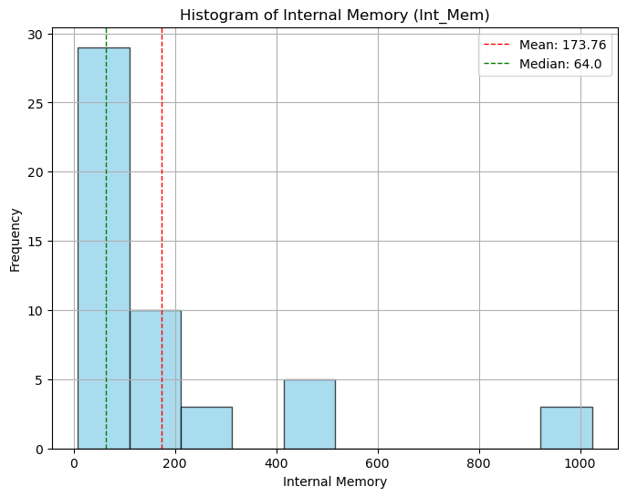

```python
# Create a histogram of the "Int_Mem" feature and also show the mean and the median
plt.figure(figsize=(8, 6))
plt.hist(df['Int_Mem'], bins=10, color='skyblue', edgecolor='black', alpha=0.7)
plt.title('Histogram of Internal Memory (Int_Mem)')
plt.xlabel('Internal Memory')
plt.ylabel('Frequency')
plt.grid(True)
mean_int_mem = df['Int_Mem'].mean()
median_int_mem = df['Int_Mem'].median()
plt.axvline(mean_int_mem, color='red', linestyle='dashed', linewidth=1, label=f'Mean: {mean_int_mem:.2f}')
plt.axvline(median_int_mem, color='green', linestyle='dashed', linewidth=1, label=f'Median: {median_int_mem}')
plt.legend()

plt.show()
```

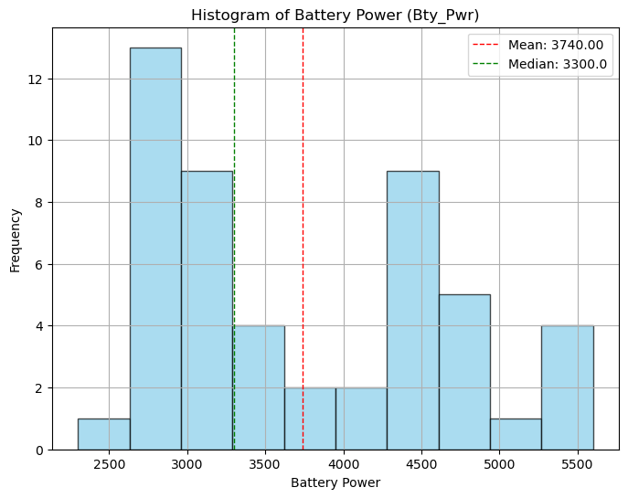

```python
# Create a histogram of the "Bty_Pwr" feature and also show the mean and the median

plt.figure(figsize=(8, 6))
plt.hist(df['Bty_Pwr'], bins=10, color='skyblue', edgecolor='black', alpha=0.7)
plt.title('Histogram of Battery Power (Bty_Pwr)')
plt.xlabel('Battery Power')
plt.ylabel('Frequency')
plt.grid(True)

mean_bty_pwr = df['Bty_Pwr'].mean()
median_bty_pwr = df['Bty_Pwr'].median()
plt.axvline(mean_bty_pwr, color='red', linestyle='dashed', linewidth=1, label=f'Mean: {mean_bty_pwr:.2f}')
plt.axvline(median_bty_pwr, color='green', linestyle='dashed', linewidth=1, label=f'Median: {median_bty_pwr}')
plt.legend()

plt.show()
```

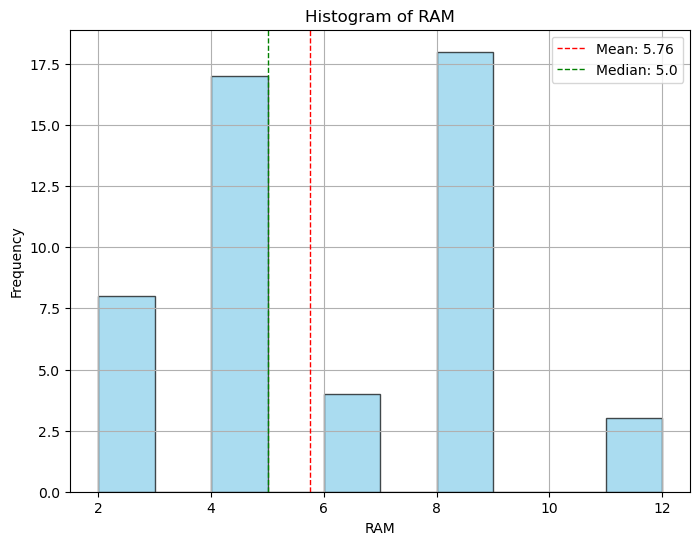

```python
# Create a histogram of the "RAM" feature and also show the mean and the median

plt.figure(figsize=(8, 6))
plt.hist(df['RAM'], bins=10, color='skyblue', edgecolor='black', alpha=0.7)
plt.title('Histogram of RAM')
plt.xlabel('RAM')
plt.ylabel('Frequency')
plt.grid(True)

mean_ram = df['RAM'].mean()
median_ram = df['RAM'].median()
plt.axvline(mean_ram, color='red', linestyle='dashed', linewidth=1, label=f'Mean: {mean_ram:.2f}')
plt.axvline(median_ram, color='green', linestyle='dashed', linewidth=1, label=f'Median: {median_ram}')
plt.legend()

plt.show()
```

```python
# The children want phones that have good internal memory, battery power and RAM
# Consider the phones that have internal memory, battery power and RAM greater than or equal to their respective mean values
# Create a logical condition for this situation and store the logical values as "con5"

mean_int_mem = df['Int_Mem'].mean()
mean_bty_pwr = df['Bty_Pwr'].mean()
mean_ram = df['RAM'].mean()

con5 = (df['Int_Mem'] >= mean_int_mem) & (df['Bty_Pwr'] >= mean_bty_pwr) & (df['RAM'] >= mean_ram)

df[con5]
```

|  | PID | Blue | Wi_Fi | Tch_Scr | Ext_Mem | Px_h | Px_w | Scr_h | Scr_w | PC | FC | Int_Mem | Bty_Pwr | RAM | Depth | Weight | Price | Px | Scr_d |
| --- | --- | --- | --- | --- | --- | --- | --- | --- | --- | --- | --- | --- | --- | --- | --- | --- | --- | --- | --- |
| 28 | SSD000L | yes | yes | yes | yes | 2580 | 2120 | 8 | 6 | 64 | 32 | 512 | 4200 | 8 | 3 | 270 | 36555 | 5469600 | 10.000000 |
| 29 | SYL888P | no | yes | yes | yes | 2580 | 2120 | 8 | 6 | 64 | 16 | 256 | 5000 | 8 | 3 | 320 | 32459 | 5469600 | 10.000000 |
| 30 | TVF078Y | yes | yes | yes | yes | 2580 | 2120 | 8 | 6 | 64 | 32 | 512 | 4860 | 8 | 3 | 90 | 29999 | 5469600 | 10.000000 |
| 32 | TYS938L | yes | yes | yes | yes | 2580 | 2120 | 8 | 6 | 64 | 32 | 1024 | 4860 | 8 | 3 | 120 | 46777 | 5469600 | 10.000000 |
| 42 | WZB298K | yes | yes | yes | yes | 2580 | 1980 | 8 | 6 | 64 | 32 | 1024 | 5600 | 8 | 3 | 160 | 39000 | 5108400 | 10.000000 |
| 44 | XTL675G | yes | yes | yes | yes | 2580 | 1980 | 10 | 8 | 64 | 32 | 512 | 4560 | 8 | 3 | 260 | 51230 | 5108400 | 12.806248 |
| 47 | ZDF789K | yes | yes | yes | no | 2880 | 2520 | 8 | 6 | 64 | 32 | 512 | 5600 | 12 | 2 | 80 | 84566 | 7257600 | 10.000000 |
| 48 | ZEO567M | yes | yes | yes | no | 2880 | 2520 | 8 | 6 | 128 | 64 | 512 | 5600 | 12 | 2 | 110 | 88999 | 7257600 | 10.000000 |
| 49 | ZZZ909X | yes | yes | yes | no | 2880 | 2520 | 8 | 6 | 128 | 64 | 1024 | 5600 | 12 | 2 | 130 | 149000 | 7257600 | 10.000000 |

Observations

The features "Int_Mem", "Bty_Pwr" and "RAM" are respectively the internal memory, battery power and RAM of the phones.

The respective means have been selected as thresholds in this case.

.In case it is too strict, we can choose the respective medians as thresholds

# Task 7 - Obtain the logical conditions for the features "Depth" and "Weight"

```python
# Let's tackle these features: "Depth", "Weight"
```

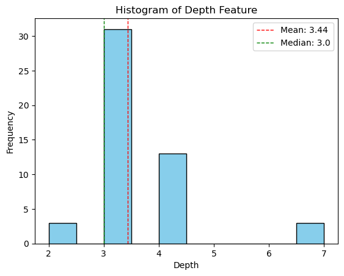

```python
# Create a histogram of the "Depth" feature and also show the mean and the median

plt.hist(df['Depth'], bins=10, color='skyblue', edgecolor='black')

mean_depth = df['Depth'].mean()
median_depth = df['Depth'].median()

plt.axvline(mean_depth, color='red', linestyle='dashed', linewidth=1, label=f'Mean: {mean_depth}')
plt.axvline(median_depth, color='green', linestyle='dashed', linewidth=1, label=f'Median: {median_depth}')

plt.xlabel('Depth')
plt.ylabel('Frequency')
plt.title('Histogram of Depth Feature')
plt.legend()

plt.show()
```

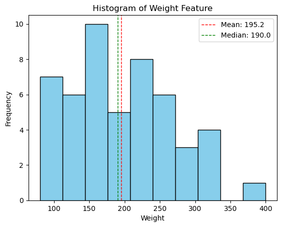

```python
# Create a histogram of the "Weight" feature and also show the mean and the median

plt.hist(df['Weight'], bins=10, color='skyblue', edgecolor='black')

mean_weight = df['Weight'].mean()
median_weight = df['Weight'].median()

plt.axvline(mean_weight, color='red', linestyle='dashed', linewidth=1, label=f'Mean: {mean_weight}')
plt.axvline(median_weight, color='green', linestyle='dashed', linewidth=1, label=f'Median: {median_weight}')
plt.xlabel('Weight')
plt.ylabel('Frequency')
plt.title('Histogram of Weight Feature')
plt.legend()
plt.show()
```

```python
# The children want phones that are light weight and slim
# Consider the phones that have depth and weight less than or equal to the respective median values in the data set
# Create a logical condition for this situation and store the logical values as "con6"

median_depth = df['Depth'].median()
median_weight = df['Weight'].median()

con6 = (df['Depth'] <= median_depth) & (df['Weight'] <= median_weight)

df[con6]
```

|  | PID | Blue | Wi_Fi | Tch_Scr | Ext_Mem | Px_h | Px_w | Scr_h | Scr_w | PC | FC | Int_Mem | Bty_Pwr | RAM | Depth | Weight | Price | Px | Scr_d |
| --- | --- | --- | --- | --- | --- | --- | --- | --- | --- | --- | --- | --- | --- | --- | --- | --- | --- | --- | --- |
| 6 | CTX123L | yes | no | yes | no | 1390 | 1080 | 6 | 3 | 8 | 4 | 32 | 3000 | 2 | 3 | 100 | 13400 | 1501200 | 6.708204 |
| 7 | DFR256N | yes | no | no | no | 2880 | 2120 | 8 | 6 | 12 | 8 | 32 | 3200 | 2 | 3 | 80 | 15600 | 6105600 | 10.000000 |
| 8 | DGS789M | yes | yes | yes | yes | 2580 | 1920 | 6 | 3 | 32 | 16 | 8 | 2800 | 6 | 3 | 120 | 27688 | 4953600 | 6.708204 |
| 9 | ENG897N | yes | yes | yes | yes | 2580 | 1980 | 5 | 3 | 64 | 32 | 64 | 4380 | 4 | 3 | 150 | 23456 | 5108400 | 5.830952 |
| 16 | PDF768G | no | no | yes | yes | 2580 | 1980 | 8 | 6 | 64 | 32 | 128 | 3300 | 4 | 3 | 160 | 22650 | 5108400 | 10.000000 |
| 20 | POP857R | no | yes | yes | yes | 1980 | 1760 | 4 | 3 | 32 | 16 | 16 | 2800 | 4 | 3 | 150 | 24560 | 3484800 | 5.000000 |
| 21 | QWR222Y | no | yes | yes | yes | 2580 | 1980 | 8 | 6 | 64 | 32 | 128 | 4400 | 4 | 3 | 160 | 21350 | 5108400 | 10.000000 |
| 22 | QZR577O | no | yes | yes | yes | 1440 | 1280 | 4 | 3 | 8 | 8 | 64 | 2800 | 8 | 3 | 170 | 16999 | 1843200 | 5.000000 |
| 23 | RAY344W | no | yes | yes | yes | 2880 | 2120 | 10 | 8 | 8 | 4 | 16 | 4800 | 8 | 3 | 170 | 18900 | 6105600 | 12.806248 |
| 24 | RBZ451D | no | yes | yes | yes | 1440 | 1280 | 6 | 4 | 8 | 4 | 32 | 2800 | 8 | 3 | 150 | 17890 | 1843200 | 7.211103 |
| 30 | TVF078Y | yes | yes | yes | yes | 2580 | 2120 | 8 | 6 | 64 | 32 | 512 | 4860 | 8 | 3 | 90 | 29999 | 5469600 | 10.000000 |
| 31 | TYQ109G | no | yes | yes | yes | 2580 | 2120 | 8 | 6 | 32 | 16 | 256 | 3300 | 8 | 3 | 110 | 45899 | 5469600 | 10.000000 |
| 32 | TYS938L | yes | yes | yes | yes | 2580 | 2120 | 8 | 6 | 64 | 32 | 1024 | 4860 | 8 | 3 | 120 | 46777 | 5469600 | 10.000000 |
| 33 | TYU444Q | no | yes | yes | yes | 2580 | 2120 | 8 | 6 | 64 | 32 | 128 | 2800 | 8 | 3 | 120 | 45680 | 5469600 | 10.000000 |
| 41 | WUV902Y | yes | yes | yes | yes | 2580 | 1980 | 8 | 6 | 48 | 16 | 128 | 3400 | 4 | 3 | 140 | 28000 | 5108400 | 10.000000 |
| 42 | WZB298K | yes | yes | yes | yes | 2580 | 1980 | 8 | 6 | 64 | 32 | 1024 | 5600 | 8 | 3 | 160 | 39000 | 5108400 | 10.000000 |
| 47 | ZDF789K | yes | yes | yes | no | 2880 | 2520 | 8 | 6 | 64 | 32 | 512 | 5600 | 12 | 2 | 80 | 84566 | 7257600 | 10.000000 |
| 48 | ZEO567M | yes | yes | yes | no | 2880 | 2520 | 8 | 6 | 128 | 64 | 512 | 5600 | 12 | 2 | 110 | 88999 | 7257600 | 10.000000 |
| 49 | ZZZ909X | yes | yes | yes | no | 2880 | 2520 | 8 | 6 | 128 | 64 | 1024 | 5600 | 12 | 2 | 130 | 149000 | 7257600 | 10.000000 |

Observations:

The features "Depth" and "Weight" are respectively the depth of the phone and the weight of the phone.

The respective medians have been selected as thresholds in this case.

In case it is too strict, we can choose the respective means as thresholds.

# Task 8 - Subset the data based on all the logical conditions

```python
# Subset the dataframe using all the logical conditions that have been stored
# Store the subset of the dataframe as a new dataframe called "df1"
# Subset the dataframe using all the logical condition
# Subset the dataframe using all the logical conditions
df1 = df[con1 & con2 & con3 & con4 & con5 & con6]
```

```python
# Get the dimensions of the dataframe
df1.shape
```

```
(3, 19)
```

```python
# Sort the dataframe according to the "Price" feature in ascending order and display it
# Sort the dataframe according to the "Price" feature in ascending order
sorted_df = df1.sort_values(by='Price')
sorted_df
```

|  | PID | Blue | Wi_Fi | Tch_Scr | Ext_Mem | Px_h | Px_w | Scr_h | Scr_w | PC | FC | Int_Mem | Bty_Pwr | RAM | Depth | Weight | Price | Px | Scr_d |
| --- | --- | --- | --- | --- | --- | --- | --- | --- | --- | --- | --- | --- | --- | --- | --- | --- | --- | --- | --- |
| 30 | TVF078Y | yes | yes | yes | yes | 2580 | 2120 | 8 | 6 | 64 | 32 | 512 | 4860 | 8 | 3 | 90 | 29999 | 5469600 | 10.0 |
| 42 | WZB298K | yes | yes | yes | yes | 2580 | 1980 | 8 | 6 | 64 | 32 | 1024 | 5600 | 8 | 3 | 160 | 39000 | 5108400 | 10.0 |
| 32 | TYS938L | yes | yes | yes | yes | 2580 | 2120 | 8 | 6 | 64 | 32 | 1024 | 4860 | 8 | 3 | 120 | 46777 | 5469600 | 10.0 |

Observations:

Based on all the logical conditions obtained through analysis of the features, we are left with three phones.

The most expensive of these phones is the "TYS938L" model and the least expensive is the "TVF078Y" model.

We could let the children choose from these three phones as per their preferences.

# Task 9 - Study the variability of the features in the original data set

```python
# Calculate the ratio of the standard deviation to the mean for all the numerical features in the dataframe
# Store these values in a new series wherein the rows are the features and the only column is the calculated ratio
# Name the series as "deviations"

data_numeric = df.select_dtypes(include=['float64', 'int64'])

std_dev = data_numeric.std()

mean_vals = data_numeric .mean()

ratios = std_dev / mean_vals

deviations = pd.Series(ratios, name="deviations")
print(deviations)
```

```
Px_h       0.257998
Px_w       0.256226
Scr_h      0.314293
Scr_w      0.407624
PC         0.715716
FC         0.712184
Int_Mem    1.506514
Bty_Pwr    0.256368
RAM        0.479075
Depth      0.306072
Weight     0.388121
Price      0.740868
Px         0.398680
Scr_d      0.340469
Name: deviations, dtype: float64
```

```python
# View the "deviations" series after sorting it in descending order

deviations_sorted = deviations.sort_values(ascending=False)
print(deviations_sorted)
```

```
Int_Mem    1.506514
Price      0.740868
PC         0.715716
FC         0.712184
RAM        0.479075
Scr_w      0.407624
Px         0.398680
Weight     0.388121
Scr_d      0.340469
Scr_h      0.314293
Depth      0.306072
Px_h       0.257998
Bty_Pwr    0.256368
Px_w       0.256226
Name: deviations, dtype: float64
```

Observations:

The ratio of the standard deviation to the mean of a feature normalises it in a way.

This allows for comparison between multiple features.

The most variable feature in the original data set is the internal memory of the phones.

The least variable feature in the original data set is the number of screen pixels in the horizontal axis.

Although most features don't seem so variable, the prices of the phones are quite variable.

Feel free to investigate what could be the cause of this difference in variability.

Note: We encourage you to extend this analysis further and see what else you can find.

Note: Please refer to the official website of Python and its libraries for various Python documentations.

# Conclusion

1. We have used concepts of descriptive statistics to study and work with a data set that contains mobile phone specifications.
2. We were able to recommend three phone models to the client which she can then propose to her children.